# 732A73: Bayesian Learning

Computer Lab 1

Oriol Garrobé, Dávid Hrabovszki

10 April 2020

# Question 1. Bernoulli…again

### (a)

Given the posterior $\theta|y \sim Beta(\alpha=7, \beta=17)$ we can compute the expected value and the standard deviation of the distribution.

The Expected value is:
$$E(\theta) = \frac{\alpha}{\alpha+\beta}=\frac{7}{7+17}=0.2917$$

The standard deviation is:

$$Sd(\theta)=\sqrt{\frac{\alpha\beta}{(\alpha+\beta)^2(\alpha+\beta+1)}}=\sqrt{\frac{7\cdot17}{(7+17)^2(7+17+1)}}=0.0909$$

Once we have the posterior we can draw random samples from it. We draw samples with different number of draws in ascending order. For each sample we compute the mean and standard deviation. Then we plot the values and study whether the mean and standar deviation get close to the true values.

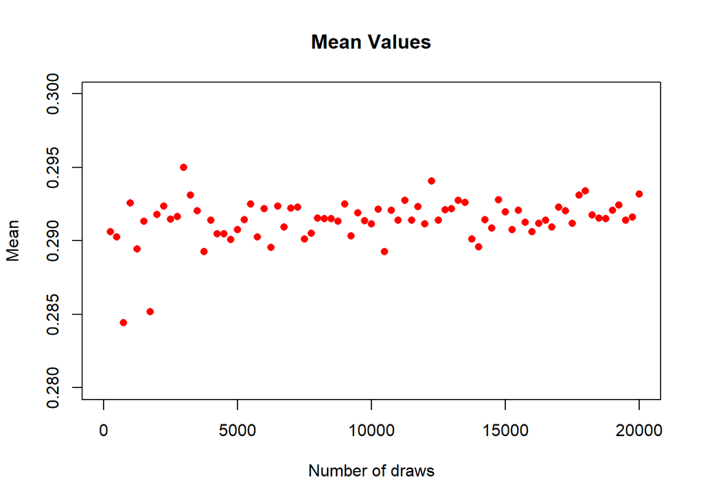

Mean values for different size samples.

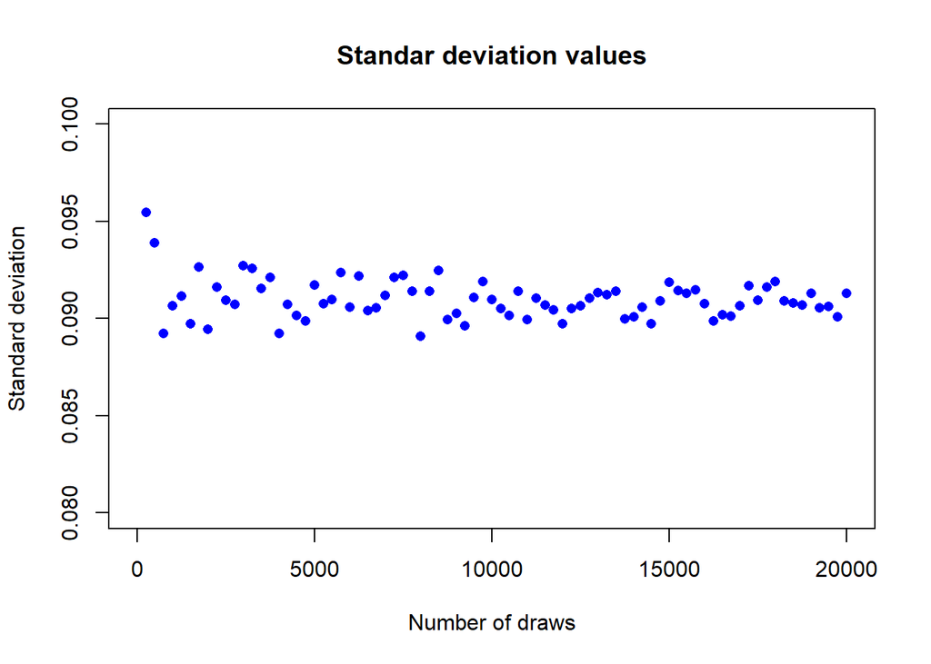

Standard deviation values for different size samples.

In Figure we can see that with a small number of samples the sample mean is already close to the true value, but the bigger the sample the closer it gets. It happens the same thing in Figure with the standard deviation values.

### (b)

We can compute the probability of $\theta > 0.3$ using the drawn sample and compare it to the exact number computed using . The value obtained from the sample is $0.4432$ and the exact probability is $0.4399472$ - see code in Appendix. We can conclude that with this sample size both probabilities are very similar.

### (c)

From this point we compute the log-odds $\phi = log\frac{\theta}{1-\theta}$ from the posterior sample.

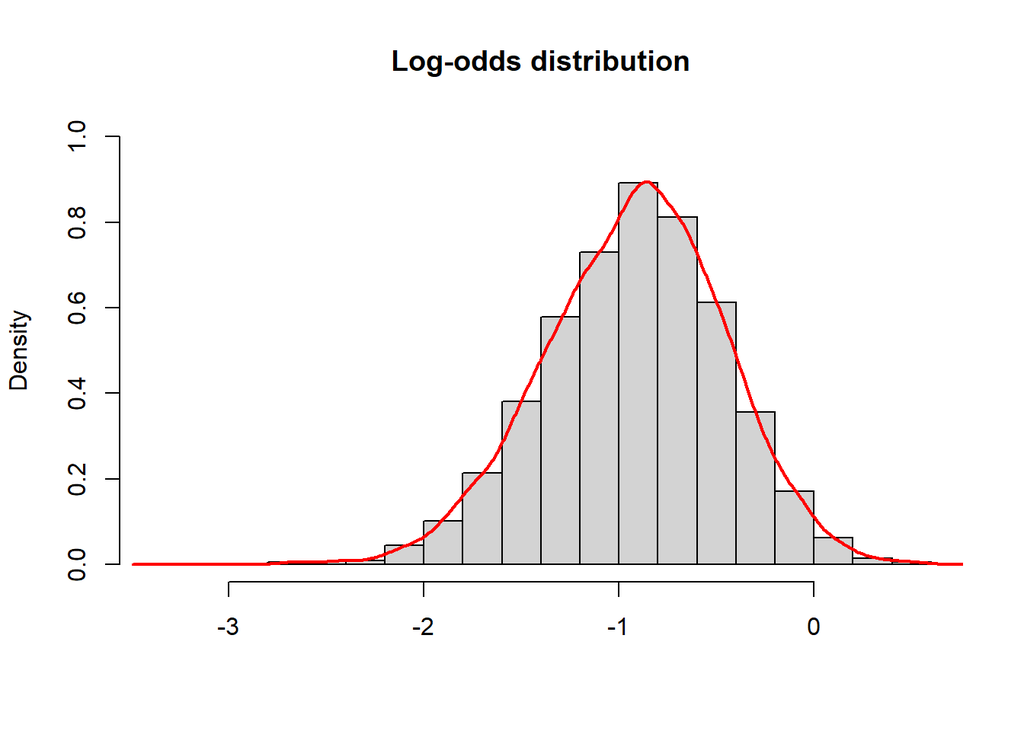

Histogram of the simulated log-odds.

In Figure we can see the distribution of the generated sample.

# Question 2. Log-normal distribution and the Gini coefficient.

In this question we are given data regarding random people income. As the data is continuous non-negative, we use the log-normal distribution with density function:
$$p(y|\mu,\sigma^2)=\frac{1}{y\cdot\sqrt{2\pi\sigma^2}}exp\left[-\frac{1}{2\sigma^2}(log(y)-\mu)^2\right],$$

where $\mu=3.7$ is assumed to be known and $\sigma^2$ follows the $Inv-\chi^2(n,\tau^2)$ distribution, where:
$$\tau^2=\frac{\sum_{i=1}^{n}(log(y_i)-\mu)^2}{n}$$

### (a)

From this point we can simulate 10,000 draws from the posterior of $\sigma^2$ using that draws sample from the $\chi^2(n)$ distribution, given that:
$$X\sim\chi^2(n)\rightarrow\frac{1}{X}\sim Inv-\chi^2(n) \rightarrow \frac{\tau^2 n}{X}\sim Scaled-Inv-\chi^2(n),$$

since we have the scale parameter $\tau^2$.Therefore, in Figure we can see the distribution of the simulated sample.

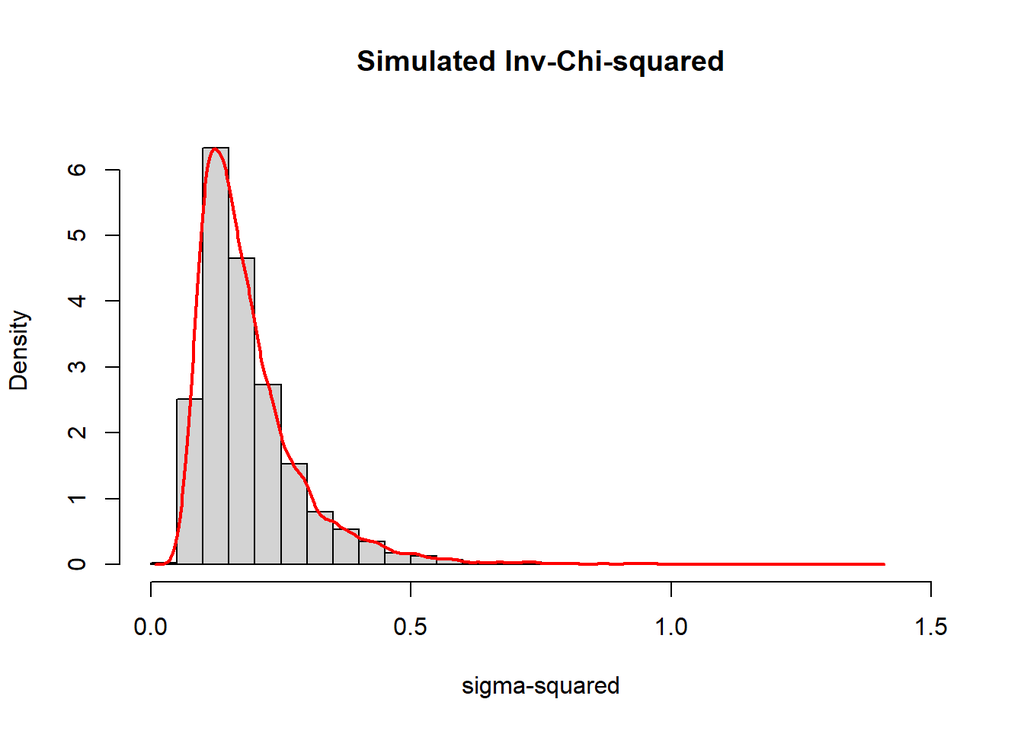

Density distribution of the simulated Inv-Chi-squared.

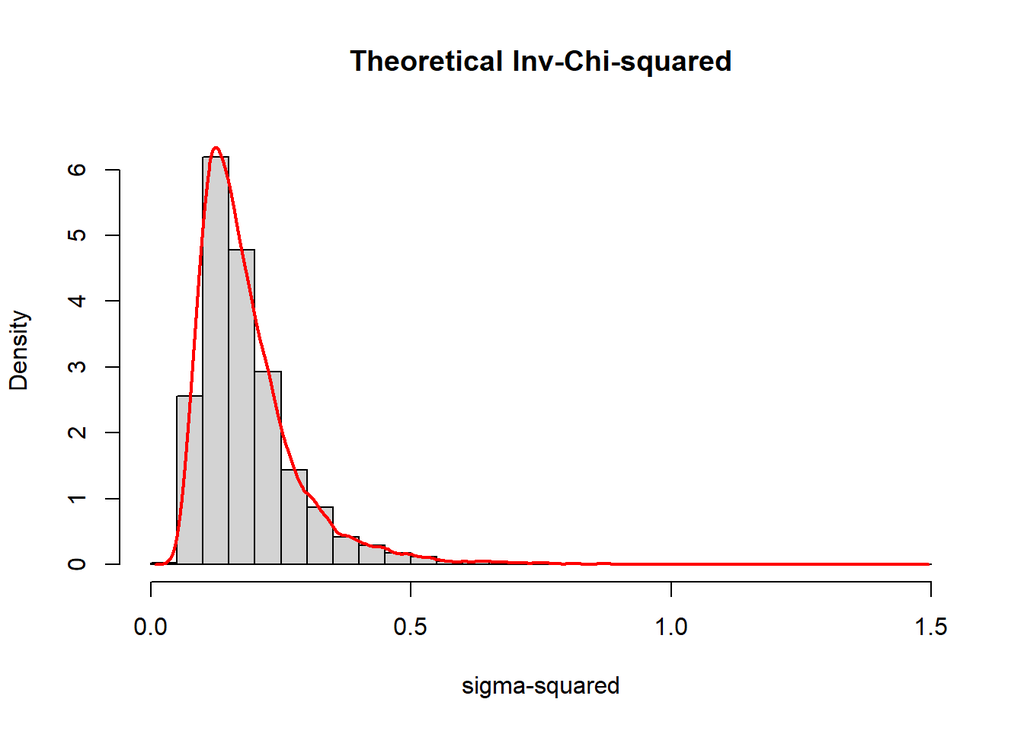

Density distribution of the Theoretical Inv-Chi-squared.

In Figure there is the distribution of 10,000 draws from the theoretical $Inv-\chi^2(n,\tau^2)$ distribution that we simulated using . We can see that both samples are equal, then we conlude that the generated sample from the $\chi^2$ distribution is correct.

### (b)

Using the the drawn sample from the posterior of $\sigma^2$ we then compute the posterior distribution of the Gini coefficient G, that is a measure of inequality, for the data set. To do so we use the Cumulative Distribution Function (CDF) for the standard normal distribution and apply the following:

$$G=2\phi\left(\frac{\sigma}{\sqrt{2}}\right) -1,$$

we then plot the result in Figure . From the plot we conclude that the Gini coefficient is closer to 0 than to 1, therefore the income of the people in the sample is more equal than not.

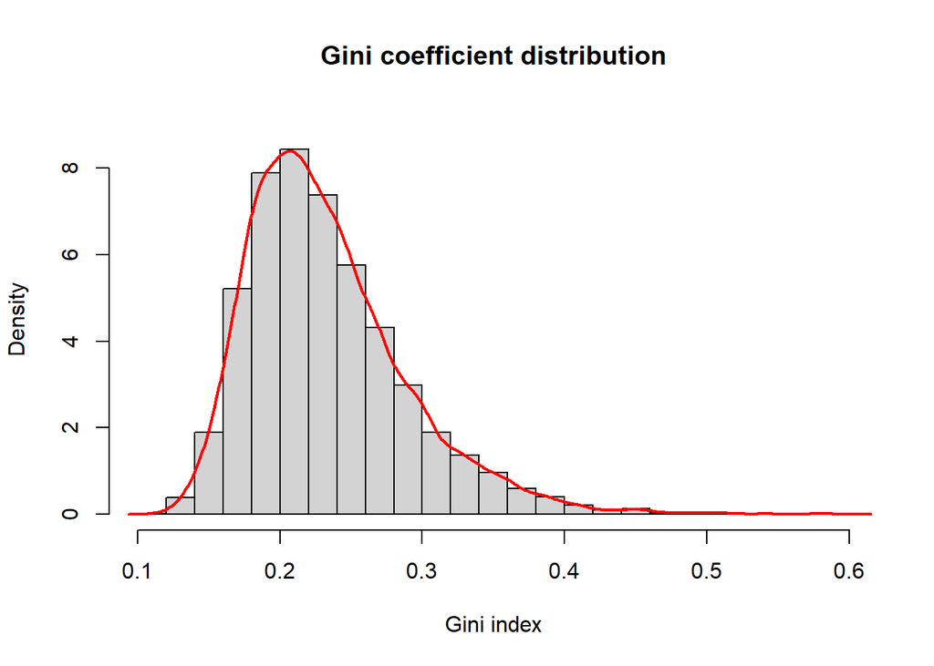

Posterior distribution of the Gini coefficient.

### (c)

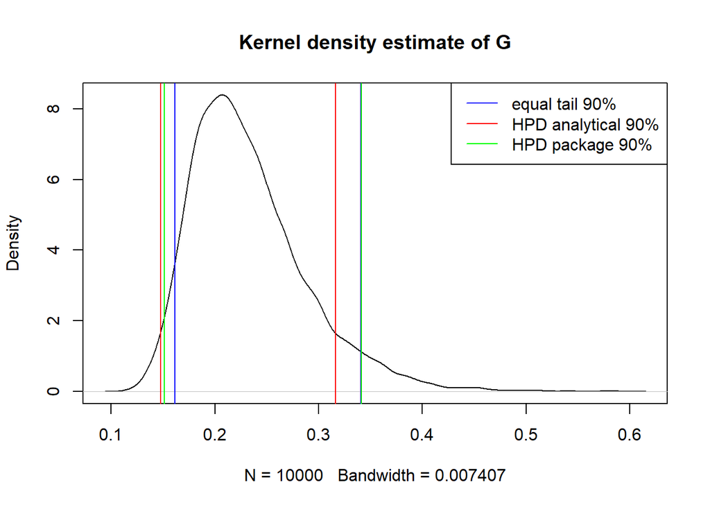

Comparison of equal tail credible intervals and highest posterior density intervals.

# 3 Bayesian inference for the concentration parameter in the von Mises distribution.

In this exercise we are given observed wind directions at a given location on ten different days. We assume that the data points are independent observations following the Von Mises distribution:

$$p(y|\mu,\kappa)=\frac{exp[\kappa \cdot cos(y-\mu)]}{2\pi I_0(\kappa)},$$

where $I_0(\kappa)$ is the modified Bessel function, $\mu$ is the mean direction and $\kappa$ is called the concentration parameter.

### (a)

Once we have the posterior distribution, we plot it for different values of $\kappa$. In Figure we can see the posterior distribution of $\kappa$ that is centered around 2 and slightly right skewed.

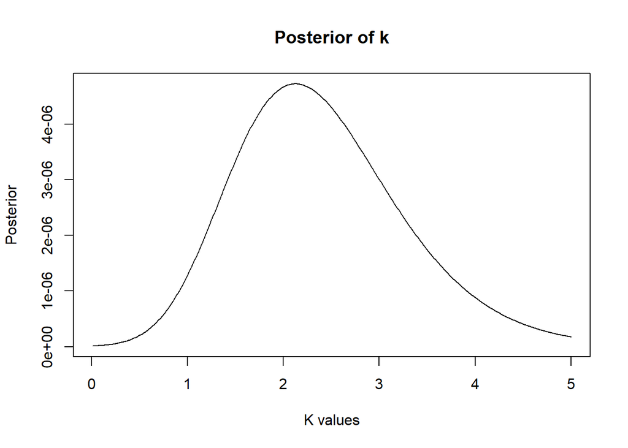

Posterior distribution of K.

### (b)

From the posterior distribution of $\kappa$ we find the mode, yielding a result of $2.12$ - see code in the Appendix.

# Appendix

```r
knitr::opts_chunk$set(echo=FALSE, eval=TRUE)
# R version
RNGversion('3.5.1')

# libraries
library(geoR)
library(HDInterval)
library(MESS)
library(ggplot2)
# Question 1. Bernoulli...again

# Parameters
n = 20
s = 5
f = n-s
alpha_0 = 2
beta_0 = 2

# (a)

draw_values <- seq(from=0, to=20000, by=250)
mean_values <- numeric(length(draw_values))
sd_values <- numeric(length(draw_values))
for (n_Draws in draw_values) {
  posterior_draw <- rbeta(n = n_Draws, shape1 = alpha_0 + s, shape2 = beta_0 + f)
  mean_values[which(draw_values==n_Draws)] <- mean(posterior_draw)
  sd_values[which(draw_values==n_Draws)] <- sd(posterior_draw)
}

# Plot - Number of draws Vs. mean
plot(draw_values, mean_values, main = "Mean Values", xlab="Number of draws",
     ylab="Mean", col="red", pch=16, ylim = c(0.28,0.3))

#Plot - Number of draws Vs. Sd
plot(draw_values, sd_values, main="Standar deviation values", ylim = c(0.08,0.1),
     xlab="Number of draws", ylab="Standard deviation", col="blue", pch=16)

#b

nDraws = 10000
posterior_draw = rbeta(n = nDraws, shape1 = alpha_0 + s, shape2 = beta_0 + f)
larger_than_03_sim = sum(posterior_draw > 0.3) / length(posterior_draw) #0.4432
larger_than_03_true = 1 - pbeta(q = 0.3, shape1 = alpha_0 + s, shape2 = beta_0 + f) #0.4399472

#c
nDraws = 10000
log_odds = log(posterior_draw/(1-posterior_draw))

#Plot
hist(log_odds, freq = F, main="Log-odds distribution", xlab = "",
     ylim = c(0,1), breaks = 20, col="lightgrey")
lines(density(log_odds), col="red", lwd=2)

# Question 2. Log-normal distribution and the Gini coeficcient

Y = c(44, 25, 45, 52, 30, 63, 19, 50, 34, 67)
logY = log(Y)
n = length(Y)
mu = 3.7
tau2 = sum((logY - mu)^2) / n
#a

# simulate from posterior for sigma^2
X = rchisq(nDraws,n)
sigma2_sim = n*tau2/X
hist(sigma2_sim, freq = F, ylim=c(0,6.5), breaks=30, xlim=c(0,1.5),
     main = "Simulated Inv-Chi-squared", xlab="sigma-squared", col="lightgrey")
lines(density(sigma2_sim), col="red", lwd=2)

# theoretical posterior for sigma^2?

sigma_posterior_draw = rinvchisq(n = nDraws, df = n, scale = tau2)
hist(sigma_posterior_draw, freq = F, ylim=c(0,6.5), xlim=c(0,1.5), breaks = 30,
     main = "Theoretical Inv-Chi-squared", xlab="sigma-squared", col="lightgrey")
lines(density(sigma_posterior_draw), col="red", lwd=2)

#b

#Gini coefficient distribution
G = 2 * pnorm(sqrt(sigma2_sim / 2)) - 1
hist(G, freq = F, ylim=c(0,9), breaks=30, main="Gini coefficient distribution",
     xlab="Gini index", col="lightgrey")
lines(density(G), col="red", lwd=2)

#c

#90% equal tail
equal_tail = quantile(G, probs = c(0.05, 0.95)) #0.1606429, 0.3368407

#HPD
densx = density(G)$x
densy = density(G)$y
sorted = cbind(seq(1,length(densy)), sort(densy, decreasing = T))
plot(sorted, type = 'l')
total_area = auc(sorted[,1], sorted[,2])

area = 0
i = 1
while (area/total_area < 0.9) {
  area = auc(sorted[1:(i+1),1], sorted[1:(i+1),2])
  i = i+1
}

cutoff = sorted[(i-1),2] # 1.773939 (subtract 1, because of the last unwanted loop iteration)
# the closest G-s from both tails from densx are 0.14747841, 0.31634166
HPD = c(0.14747841,0.31634166)

# alternative using package HDInterval
hdi(G, credMass = 0.9) #0.1513655, 0.3413572
hdi = c(0.1513655, 0.3413572)

# plot of intervals
plot(density(G), main = "Kernel density estimate of G")
abline(v = equal_tail, lwd = 1, col = "blue")
abline(v = HPD, lwd = 1, col = "red")
abline(v = hdi, lwd = 1, col = "green")
legend(x = "topright", legend=c("equal tail 90%","HPD analytical 90%", "HPD package 90%"),
       col = c("blue", "red", "green"), lwd = 1)

# 3 Bayesian inference for the concentration parameter in the von Mises distribution.

y = c(40, 303, 326, 285, 296, 314, 20, 308, 299, 296)
y_rad = c(-2.44, 2.14, 2.54, 1.83, 2.02, 2.33, -2.79, 2.23, 2.07, 2.02)
mu = 2.39


#a
k = seq(0.01,5,by = 0.01)

posterior_k = 1 / ((2*pi*besselI(k, nu = 0))^10) *
  exp(k * (sum(cos(y_rad-mu))-1))

plot(k,posterior_k, type = 'l', main = 'Posterior of k', xlab="K values", ylab="Posterior")

#b
k[which.max(posterior_k)] #2.12
```